# Day 14

## The Normal Distribution

The **normal distribution** is (un)arguably the most important probability distribution used in statistics

> We’ve encountered it already in this course

The shape of a *normal distribution curve* is **symmetric**, **bell-shaped**, centered around its **peak**

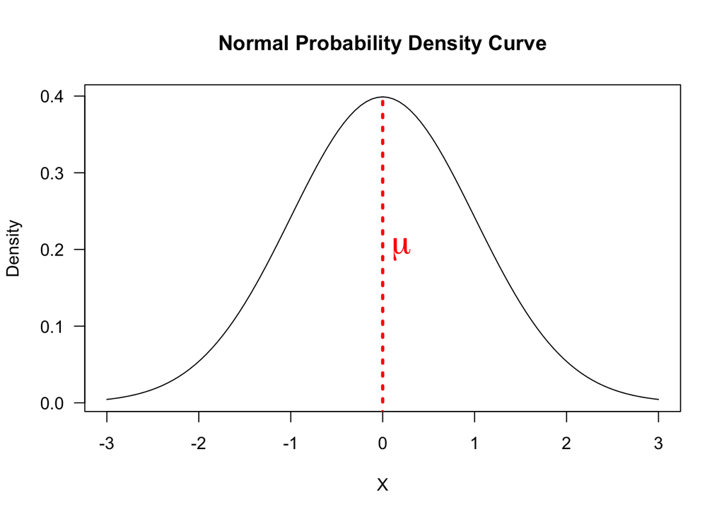

A population that is represented by a normal curve is said to be **normally distributed**

- or to have a *normal distribution*

Any **normal r.v.** is complete characterized by specifying values for its **mean** and **standard deviation**

$\mu$ is both the **mean** and **median** (due to symmetry) and is called a **location** parameter

- if the value of $\mu$ is changed, the whole distribution is shifted

$\sigma$ is the **standard deviation** and referred to as the **scale** parameter

- the larger $\sigma$ is, the more “squished” the distribution looks

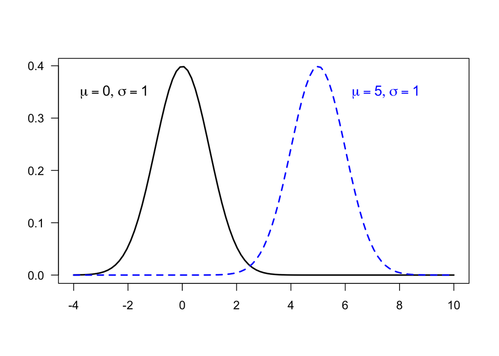

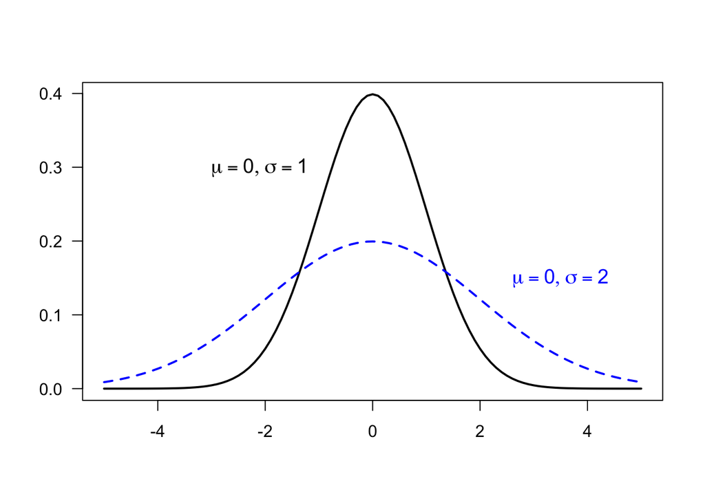

Recall a special feature of **approximately bell-shaped** distributions:

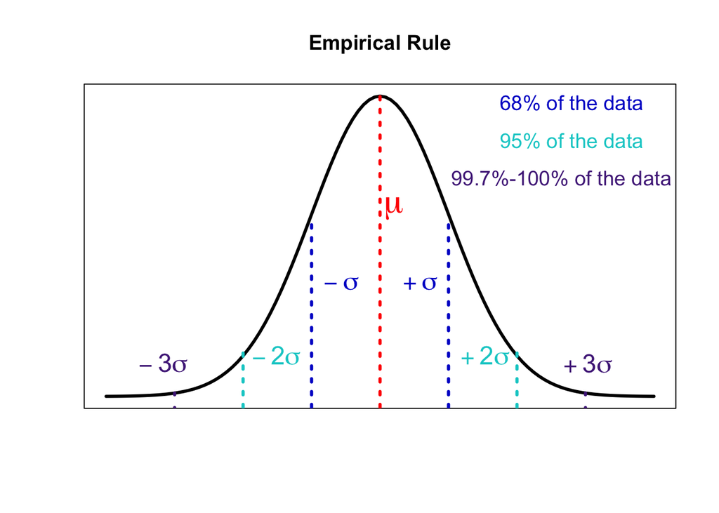

### Standard Normal Distribution

A **standard normal distribution** is a normal distribution with:

- $\mu=0$
- $\sigma = 1$
  - What is the total area under the standard normal curve?

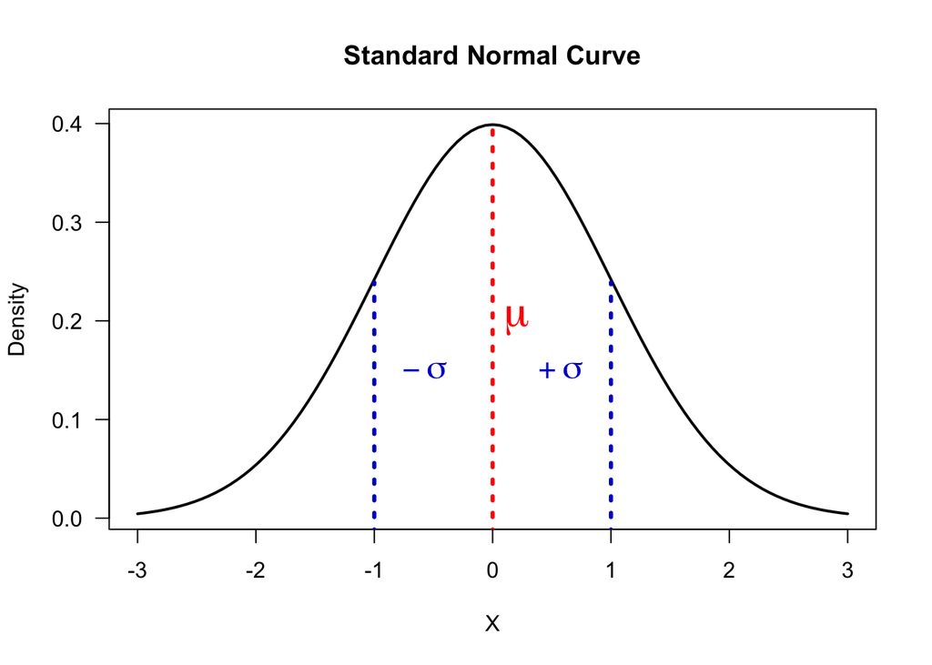

We use the letter $Z$ to represent a standard normal random variable (referring to $z$-score)

The probability that a **standard normal random variable** $Z$ is between $a$ and $b$ ($P(a<Z<b)$) is equal to the **area under the standard normal curve** over the interval $[a,b]$

- As we’ve discussed in gruesome detail, we need calculus to manually compute this area
  - Regardless of *if* you know calculus, for this course you do not

### Reframing Continuous Probability

> Inevitably, I’d like to see this as the major way that I instruct this topic

> Suppose that the heights of American men (20 years or older) are *approximately normal* with a mean of 70 inches and a standard deviation of 4 inches. What proportion of American men are less than 6 feet tall?

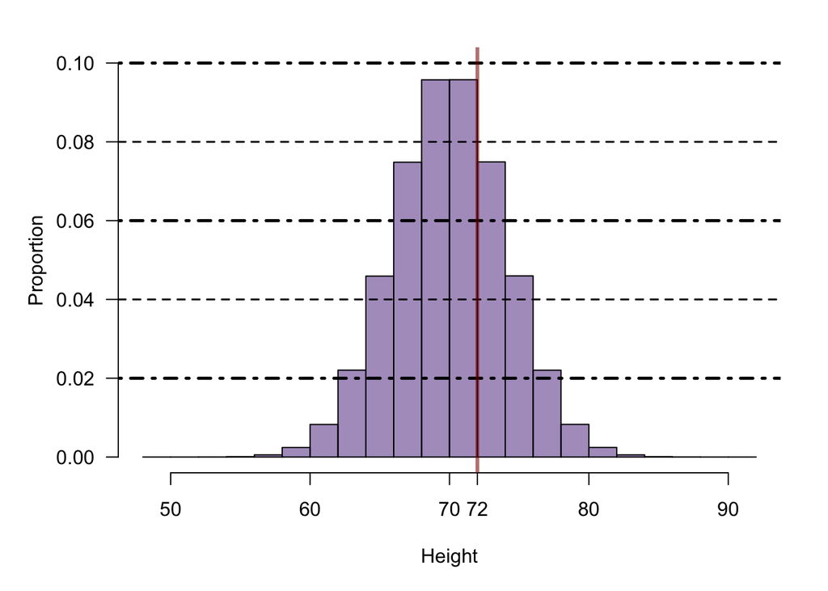

A way that we could solve this, given our current understanding of the class:

1. Find the proportion for each “Class” (58-60, 60-62, …)
2. Add them all up
3. Multiply them by the class index (in this context, 2)

> Let’s try that:

$$\begin{array}{|c|c|c|c|}
\hline
58 & 60 & 62 & 64 & 66 & 68 & 70 & \text{Total} \\
\hline
0.005 & 0.01 & 0.02 & 0.045 & 0.075 & 0.095 & 0.095 & 0.345 \\
\hline
\end{array}$$

$$0.345*2=0.69$$

What we’ll be learning in the coming weeks is a method to do the same thing, but with $z$-scores:

$$P(X\leq 72) = P\left(Z \leq {72-70 \over 4}\right) = P(Z \leq 0.5)=0.6915$$

Use $z$-table (or Table A.2 in the textbook) to compute:

1. $P (Z < 1.26)$ (i.e., area to the left of $z = 1.26$);
2. $P (Z > −0.58)$ (i.e., area to the right of $z = −0.58$);
3. $P (−0.58 < Z < 1.26)$ (i.e., area between $z = −0.58$ and $z = 1.26$).

**Part a**

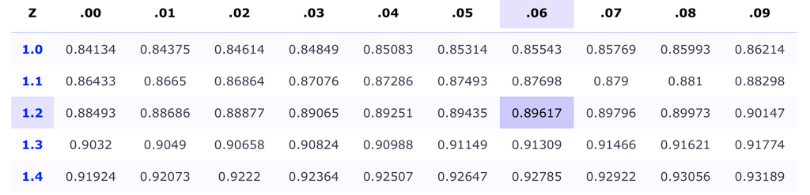

- The value $0.8962$ is the area to the **left** of $z = 1.26$

**Part b**

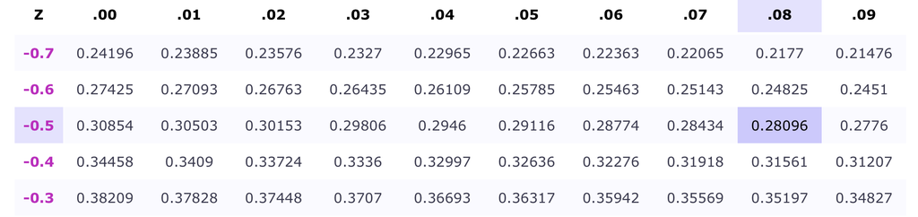

- Remember that our $z$-table is telling use area to the **left**
  - Use the complement rule to find the area to the right of $z=-0.58$

**Part c**

Use the $z$-table to find the area under the standard normal curve in the shaded region:

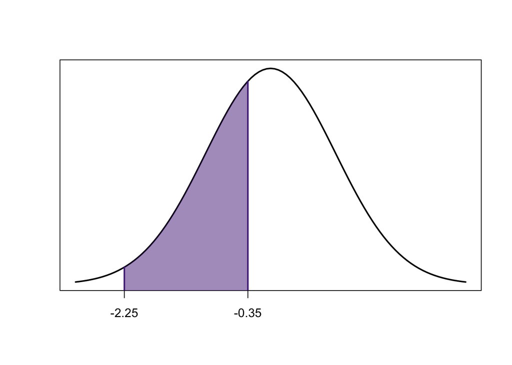

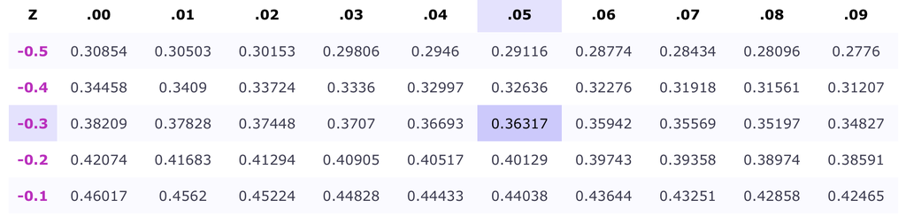

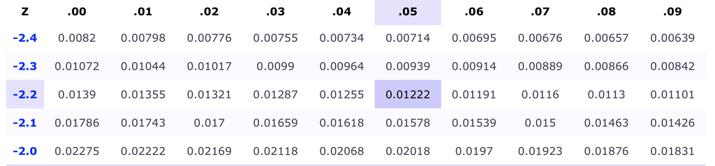

Using the symmetry of a normal density curve and the fact that $P (Z < −1) = 0.1587$, compute the following probabilities. (You don’t need $z$-table for this question.)

1. $P(Z \geq 1)$
2. $P(0\leq Z\leq 1)$
3. $P(−1<Z<1)$

## Finding a z Score for a given area

Often we need to find the $z$-score that corresponds to a given area under the standard normal curve (e.g. percentile values).

- Recall that the numbers in the body of $z$-table represents the area to the left of the corresponding z-score.
- The next example shows how to use $z$-table to find the $z$-score given an area under the standard normal curve.

Use the $z$-table to find the $z$-score that has an area of $0.68$ to its right.

- Sketch your curve:

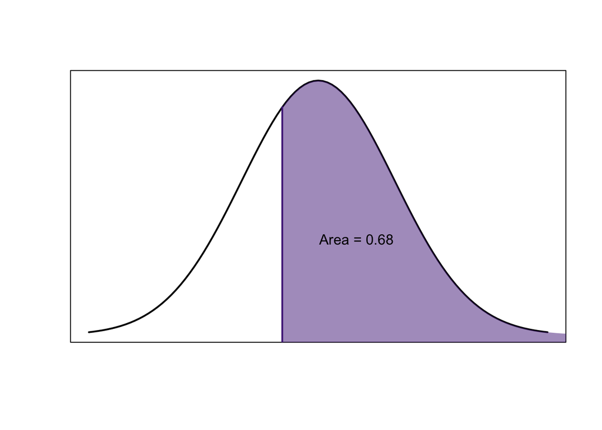

Since we want area to the left in order to use a $z$-table, we need to take the complement:

$$1-0.68=0.32$$

Then, recognizing that approximations will **never** be perfect, we’ll search our $z$-table for a value that’s $\approx 0.32$:

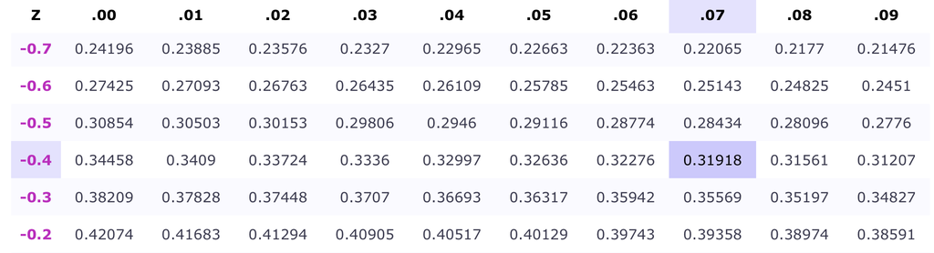

- Approximations are a *slight touchy feely art*
  - We can see that $|0.32-0.32276|=0.00276$ and $|0.32-0.31918|=0.00082$
  - It should be clear that $0.00276>0.00082$
  - So $z=-0.47$ is a better approximation of our given area than $z=-0.46$
  - In practice you can do a lot of this determination with gut feeling and be effective
- Our final conclusions is that $z=-0.47$

Use z-table to find the value of $z_0$ such that $P(−z_0 ≤ Z ≤ z_0) = 0.95$